# Data Science II

Session 1: Quarto for Spatial Reporting

Bogdan G. Popescu

bgpopescu@tec.mx

Tec de Monterrey

## GIS Is More Than Making Maps

Making the map is usually the last step. The method is everything before it.

A spreadsheet can tell you how many clinics Yucatán has. Only location can tell you:

- **How far** is the nearest one from each village?
- **How many** people live within 8 km of one?
- **Where** is the gap that the next clinic should fill?

The new idea this term is joining tables by geometry rather than by a shared id.

## The Sessions

|  | You learn | So you can judge |
| --- | --- | --- |
| **1** | Quarto for spatial reporting | what a reader actually receives |
| **2** | coordinates and CRS | whether an analysis measures in metres or degrees |
| **3** | `sf` objects, joins, choropleths | whether a map shows a rate, or just population |
| **4** | joins by location, distance, buffers | whether *nearest* and *within* mean what you intended |
| **5** | rasters and zonal statistics | whether resolution and aggregation fit the question |

Everything is done in R and Quarto rather than in ArcGIS or QGIS.

## Where This Is Going

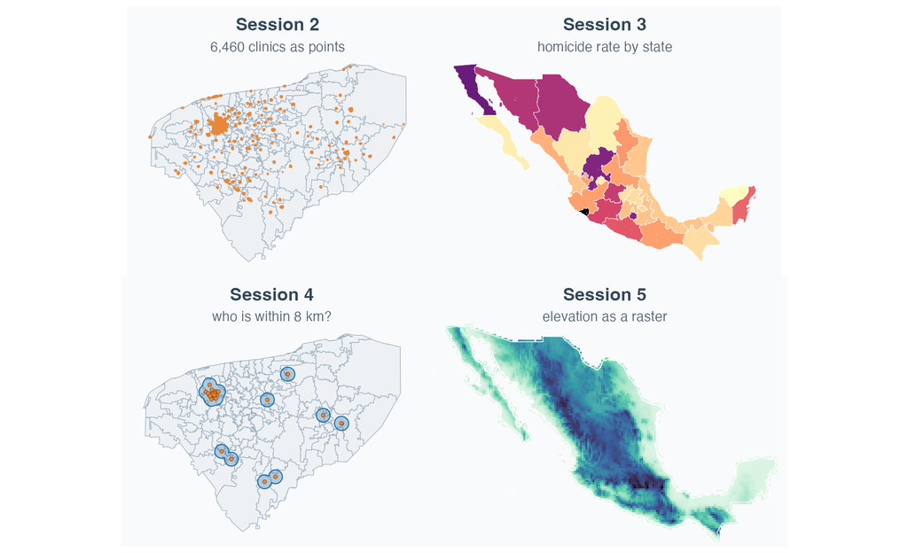

All of these come from the data in your `data/` folder, and you will build them yourself.

## Ask AI to Do the Analysis

> *“Calculate the distance from every Mexican municipality to the nearest hospital.”*

You will get fifteen lines of clean, well-commented `sf` code in about four seconds.

It will run. It will produce 2,469 numbers.

The question is whether those numbers mean what you think they mean.

## The Questions It Did Not Ask

- are the layers in **degrees or metres** — and are the distances therefore meaningful? *(today)*
- does **nearest** mean the centroid, the boundary, or where people actually live? *(Session 4)*
- did the join quietly **duplicate** municipalities? *(Session 4)*
- what happened to the **islands**? *(today)*
- is a **straight line** what you want, or travel time on a road?

None of these is a coding question. Every one of them changes the answer, and none of them throws an error.

**Note**

By the end of these sessions you should be able to ask for an analysis like this, read what comes back, say where it is wrong, fix it, and defend the version you hand in.

## What Does “Nearest” Mean?

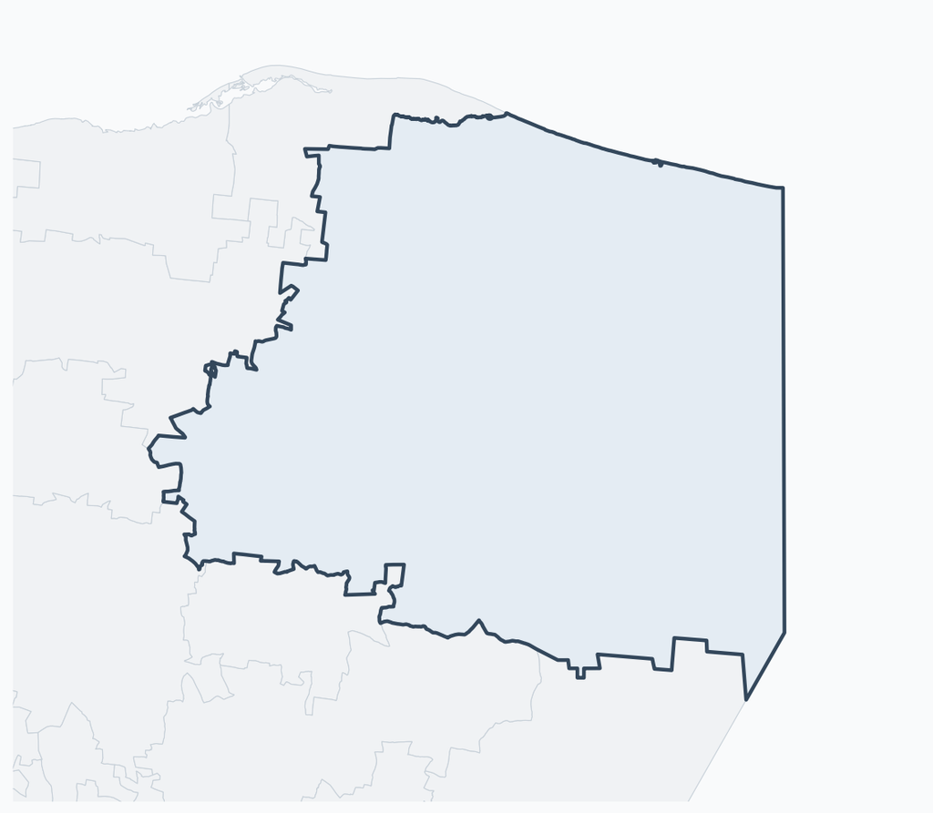

**Tizimín**, one municipality in Yucatán.

## What Does “Nearest” Mean?

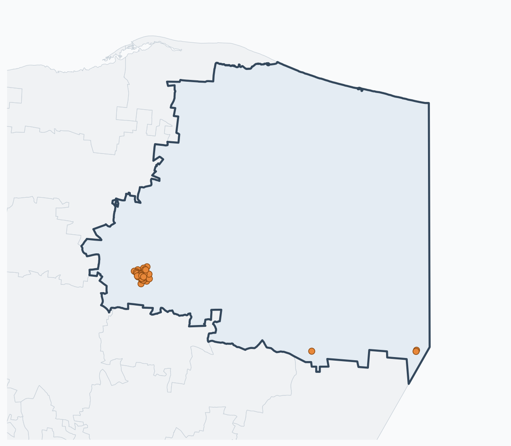

It contains **129 clinics**.

## What Does “Nearest” Mean?

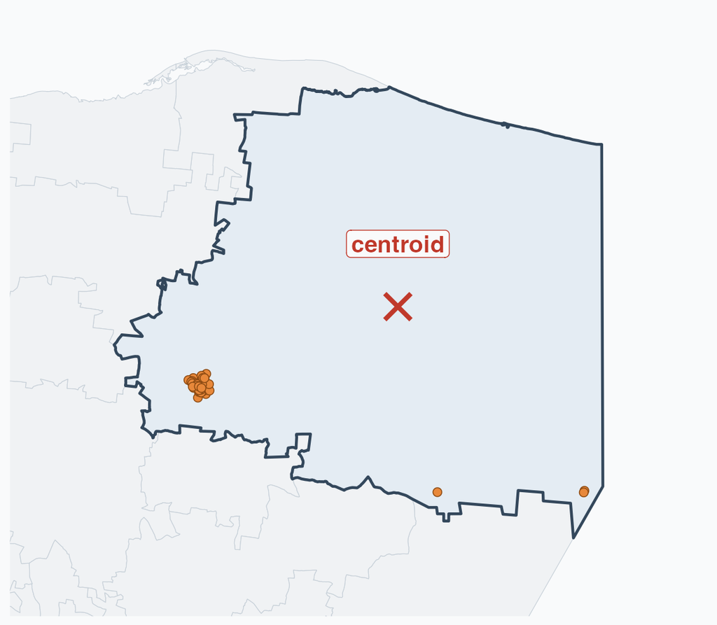

Ask for *the distance to the nearest hospital*. The obvious code takes the **centroid**.

## What Does “Nearest” Mean?

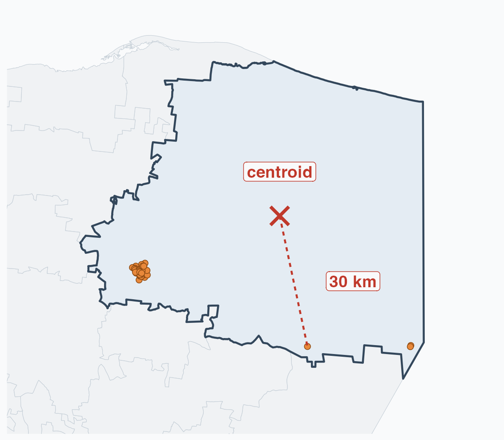

It answers **30 km**.

## What Does “Nearest” Mean?

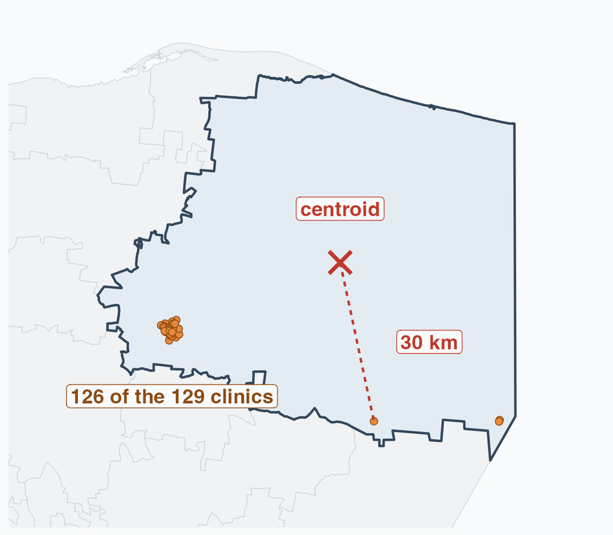

But **126 of the 129** are right there, in the town.

The code is right. The question was wrong: nobody lives at the centroid.

## One Centroid, 129 Distances

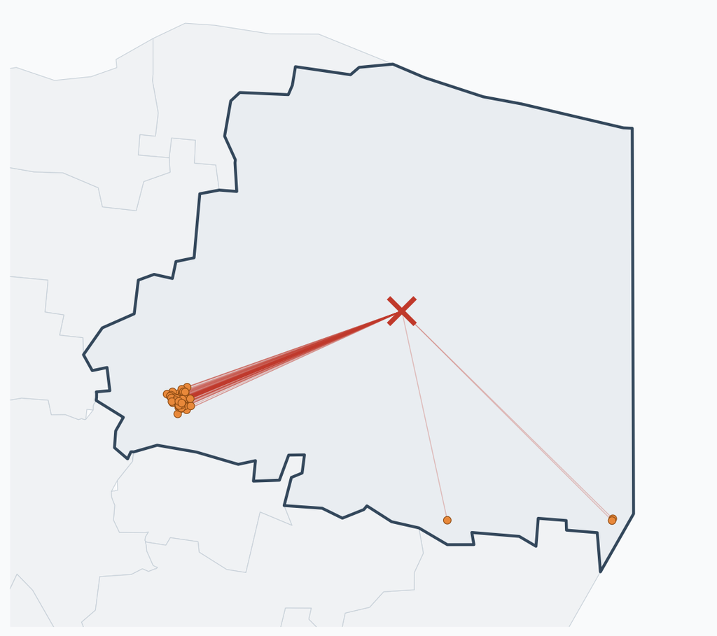

The centroid has a distance to **every** clinic, not just the nearest.

## Which Distance Do You Report?

| **30.0 km** | to the nearest clinic |
| --- | --- |
| **33.6 km** | median of all 129 |
| **33.8 km** | mean of all 129 |
| **41.8 km** | to the farthest |

Nearest, median or mean — they are all between 30 and 42 km. Picking a different statistic does not help.

The problem is not which summary we take. It is **where we measured from**.

## Nobody Lives at the Centroid

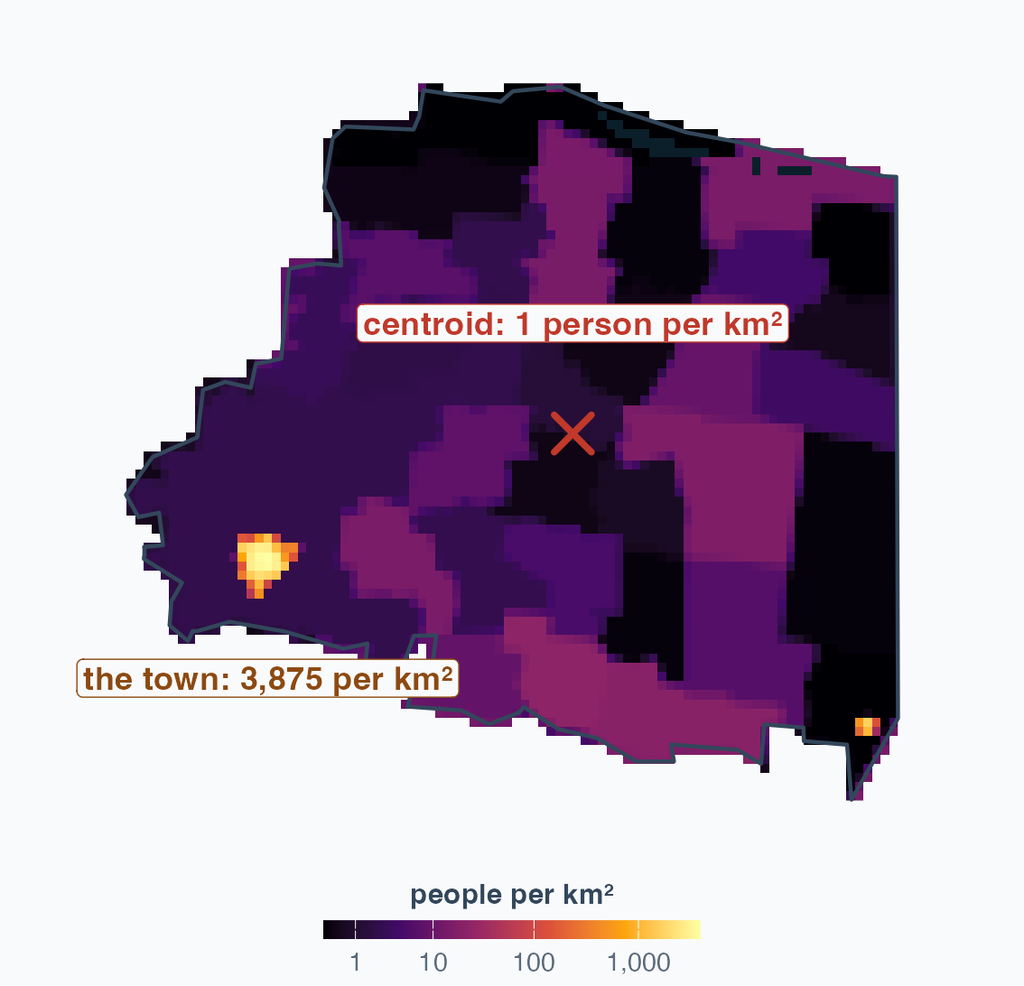

The centroid’s square kilometre holds **one person**. The town’s holds **3,875**.

## So Ask About Communities, Not Polygons

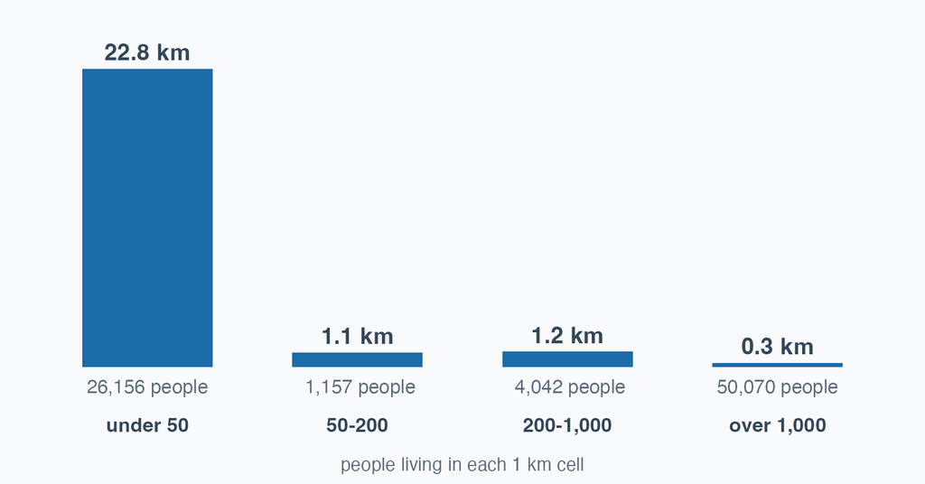

Every populated square kilometre of Tizimín, grouped by how many people live in it.

## So Ask About Communities, Not Polygons

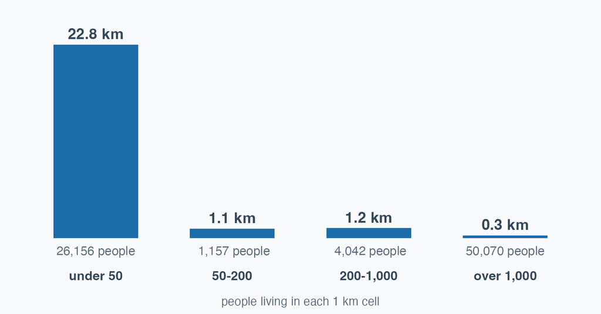

**50,070 people** are 0.3 km from a clinic. **26,156** are 22.8 km away. That is the finding.

## That Is the Point of This Course

The computer did not get 30 km wrong. We asked it to measure from a square kilometre where **one person** lives.

Every correction along the way was a **question**, not a function: measure from where people are, group by community rather than by polygon.

And the answer was never one number — **0.3 km** for 50,070 people, **22.8 km** for 26,156.

Over these sessions you should be able to ask for an analysis like this, see what is wrong with it, fix it, and defend what you hand in.

## What You’ll Learn Today

1. **Quarto** as the container for spatial work — built from scratch, click by click
2. The four Quarto settings that matter for **maps**
3. Why the Earth’s shape forces us to think about **coordinate reference systems**
4. **Geographic** vs. **projected** systems, and what every projection distorts
5. **Vector layers**: points, lines, polygons
6. Reading and mapping a real **shapefile** of Mexico

By the end, you will have a Quarto document that renders a map of Mexico.

## Before We Start: Your Folder

Every line of code in these slides runs on your machine, provided your folders look like this:

```
ciencia_datos_2/
├── data/
│   ├── gadm41_MEX_shp/       <- Mexico boundaries (GADM)
│   ├── denue/                <- DENUE point data
│   └── mex_formats/          <- the same states as .geojson and .gpkg
└── session1/
    └── my_notes.qmd          <- you work here
```

Code in these slides reads `../data/...` — **up one level, then into `data`**. Keep that shape and everything copies and pastes without edits.

## Quarto: Three Layers

Every `.qmd` file has exactly three kinds of content:

1. **YAML header** — metadata and output settings, between `---` fences
2. **Markdown** — your prose, headings, tables, links
3. **Code chunks** — R that runs when you render

Let’s build one together, from an empty RStudio window.

## Step 1: Open RStudio

[figure not shown]

Nothing open yet — just the **Console** on the left and an empty **Environment** on the right.

## Step 2: File → New File → Quarto Document

[figure not shown]

Note **Quarto Document** and **Quarto Presentation** are separate entries. Today: Document.

## Step 3: The New Document Dialog

[figure not shown]

## Step 4: The Visual Editor

[figure not shown]

RStudio gives you a template document. Headings look like headings; code chunks look like boxes.

## Step 5: The Source Editor

[figure not shown]

The **same file**, shown as raw text. `## Quarto` is a heading; `` ```{r} `` opens a chunk.

## Visual or Source?

**Visual**

- Easier for prose
- Tables and links via toolbar
- Good when writing the report

**Source**

- You see exactly what is in the file
- Necessary for chunk options
- Good when debugging

**Note**

Everything in these slides is written in **Source**. When something goes wrong, Source is where you find out why.

## Step 6: Clear the Template

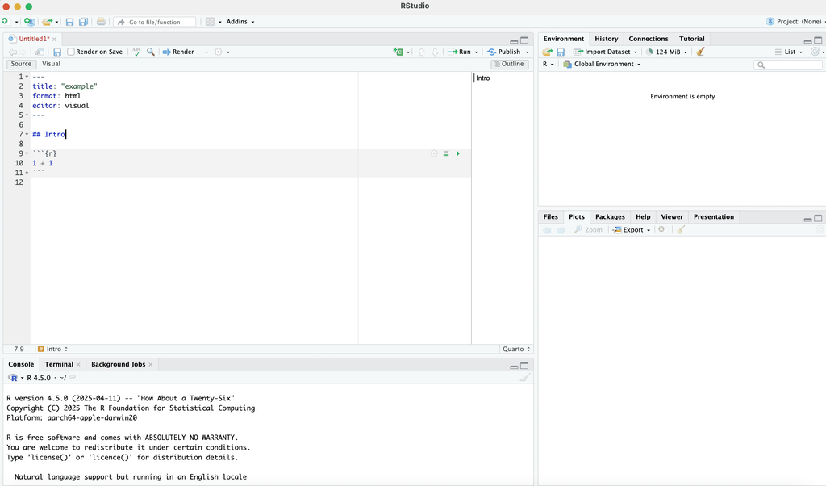

Delete the sample text. Keep the YAML header, one heading, and one chunk.

## Step 7: Save It

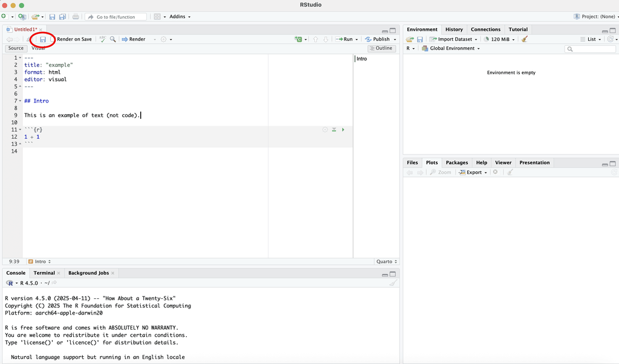

**Warning**

Save **before** you render. An unsaved document has no folder, so relative paths like `data/...` have nothing to be relative *to*.

## Step 8: Now It Has a Name

[figure not shown]

The tab now reads `example.qmd`, and the tooltip shows the **Render** shortcut: `Shift+Cmd+K` (`Shift+Ctrl+K` on Windows).

## Step 9: Write Some Text

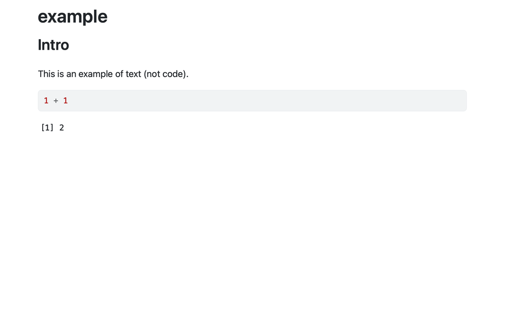

Plain prose between the chunks. This is the part that makes it a *report* and not a script.

## Step 10: Comment Your Code

[figure not shown]

Inside a chunk, `#` starts a comment — exactly as in any R script.

## Step 11: Run the Chunk

[figure not shown]

The green **▶** runs the chunk. Output appears *inline*, under the chunk, **and** in the Console.

## Step 12: Insert Another Chunk

[figure not shown]

The circled button inserts a new chunk — or press `Option+Cmd+I` (`Alt+Ctrl+I` on Windows). Learn this shortcut; you will use it constantly.

## Step 13: Render

[figure not shown]

## Step 14: The Result

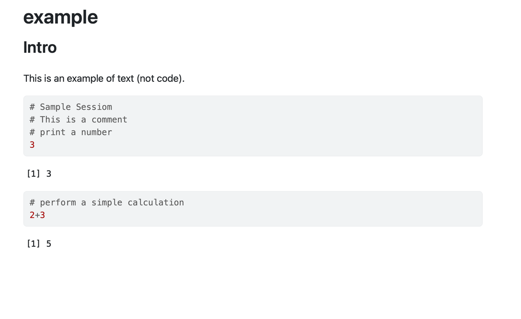

Prose, code, and output — one document, reproducible from source. **That is the whole point.**

## The YAML Header

```yaml
---
title: "Access to Health Services"
author: "Your Name"
date: "2026-09-15"
format: html
toc: true
toc-title: "Contents"
---

# Introduction

This is an example.
```

- `format: html` — what gets produced
- `toc: true` — table of contents
- `toc-depth: 2` — how many heading levels
- `toc-title:` — rename it

YAML is **whitespace-sensitive**. Two spaces of indentation mean something; a tab breaks it.

## What `toc-depth` Does

The **same document**, rendered three times. Only `toc-depth` changes.

`toc-depth: 1`

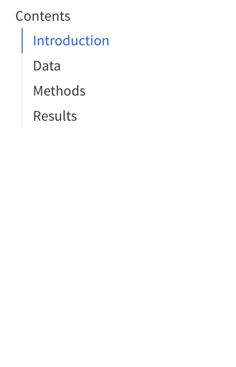

`toc-depth: 2`

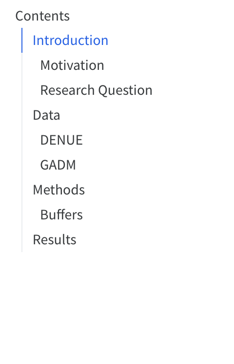

`toc-depth: 3`

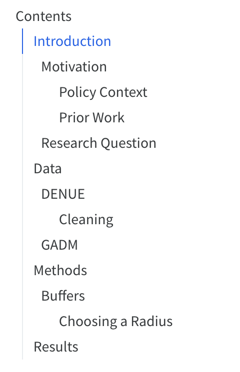

Each level deeper adds the next rank of headings — `#`, then `##`, then `###`. The default is **3**.

## Code Chunks

### Embedding Code

This is how we include code in our documents.

````markdown
---
title: "Statistical Analysis Report"
author: "Your Name"
date: "2024-11-05"
format: html
toc: true
toc-title: "Contents"
---

# Introduction

This is an example.

This is an equation: $E=mc^{2}$

```{r}
summary(mtcars)
```
````

[interactive chart not shown]

## Code Chunks

### Embedding Code

Both the code and its output appear.

````markdown
---
title: "Statistical Analysis Report"
author: "Your Name"
date: "2024-11-05"
format: html
toc: true
toc-title: "Contents"
---

# Introduction

This is an example.

This is an equation: $E=mc^{2}$

```{r}
#| echo: true
#| eval: true
summary(mtcars)
```
````

[interactive chart not shown]

## Code Chunks

### Embedding Code

Only the **output**, with the code hidden.

````markdown
---
title: "Statistical Analysis Report"
author: "Your Name"
date: "2024-11-05"
format: html
toc: true
toc-title: "Contents"
---

# Introduction

This is an example.

This is an equation: $E=mc^{2}$

```{r}
#| echo: false
#| eval: true
summary(mtcars)
```
````

[interactive chart not shown]

## Code Chunks

### Embedding Code

Only the **code**, without running it.

````markdown
---
title: "Statistical Analysis Report"
author: "Your Name"
date: "2024-11-05"
format: html
toc: true
toc-title: "Contents"
---

# Introduction

This is an example.

This is an equation: $E=mc^{2}$

```{r}
#| echo: true
#| eval: false
summary(mtcars)
```
````

[interactive chart not shown]

## Code Chunks

### Embedding Code

Many times you will have seen annoying library messages:

````markdown
---
title: "Statistical Analysis Report"
author: "Your Name"
date: "2024-11-05"
format: html
toc: true
toc-title: "Contents"
---

# Introduction

This is an example.

This is an equation: $E=mc^{2}$

```{r}
#| echo: true
#| eval: false
summary(mtcars)
```

```{r}
library(dplyr)
```
````

[interactive chart not shown]

## Code Chunks

### Embedding Code

To keep them out of the document, you should do:

````markdown
---
title: "Statistical Analysis Report"
author: "Your Name"
date: "2024-11-05"
format: html
toc: true
toc-title: "Contents"
---

# Introduction

This is an example.

This is an equation: $E=mc^{2}$

```{r}
#| echo: true
#| eval: false
summary(mtcars)
```

```{r}
#| warning: false
#| message: false
library(dplyr)
```
````

[interactive chart not shown]

## Installing What You Need

Run these **once**, in the Console — not in your document. One line at a time:

```r
install.packages("sf")          # spatial objects: the core of this course
install.packages("tidyverse")   # brings ggplot2, dplyr, readr and friends
```

**Warning**

`sf` is the one that can fail. It needs GDAL, GEOS and PROJ underneath. On Mac and Windows the binary from CRAN includes them; on Linux install `libgdal-dev`, `libgeos-dev` and `libproj-dev` first.

## Installing What You Need

The rest, in the order you will meet them:

```r
install.packages("spData")        # example world data          (today)
install.packages("cowplot")       # plot themes                 (today)
install.packages("ggspatial")     # map layers and scale bars   (today)
install.packages("patchwork")     # plots side by side          (Session 3)
install.packages("classInt")      # choropleth class breaks     (Session 3)
install.packages("viridis")       # colour scales               (Session 3)
install.packages("leaflet")       # interactive maps            (Session 3)
install.packages("terra")         # rasters                     (Session 5)
install.packages("tidyterra")     # rasters with ggplot         (Session 5)
install.packages("exactextractr") # zonal statistics            (Session 5)
```

## `sf` Is Worse Than `dplyr`

It reports the geometry type, the bounding box and the full CRS on **every single read**.

````markdown
```{r}
#| warning: false
#| message: false
mex <- st_read("../data/gadm41_MEX_shp/gadm41_MEX_1.shp",
               quiet = TRUE)
```
````

**Important**

You need **both**. `quiet = TRUE` silences `sf`’s own reporting; the chunk options silence R’s warnings and messages. They are different channels.

## A First Map of Mexico

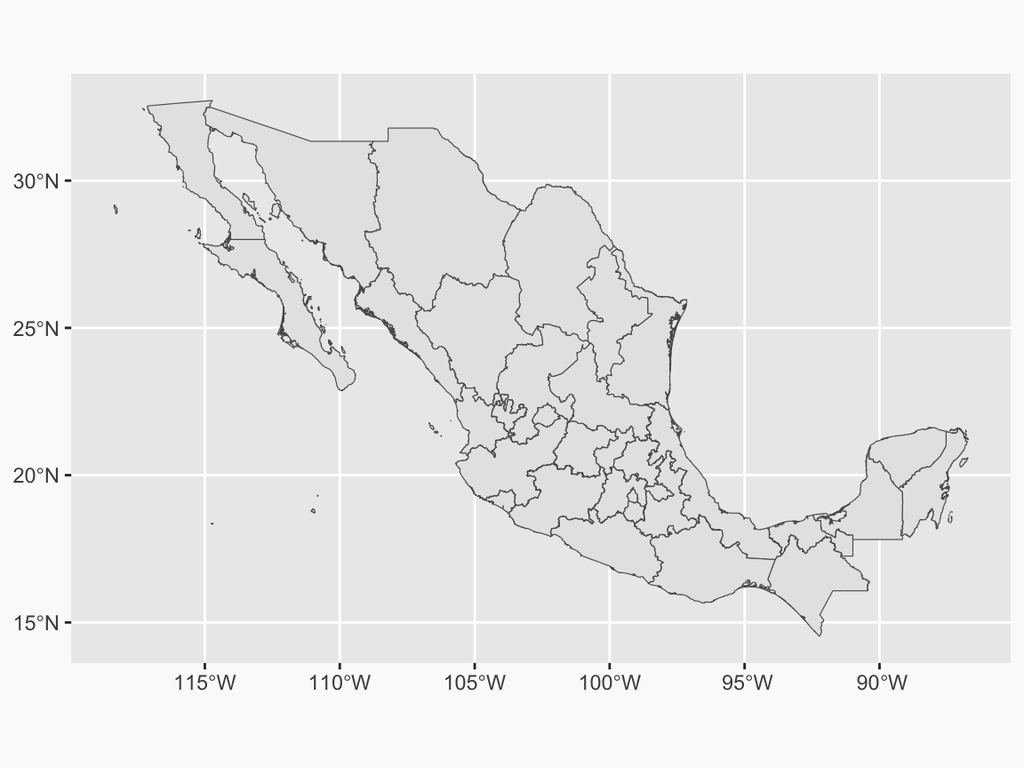

```r
library(sf)
library(ggplot2)

#Step1: Read it, quietly
mex <- st_read(
  "../data/gadm41_MEX_shp/gadm41_MEX_1.shp",
  quiet = TRUE)

#Step2: Draw it
ggplot() +
  geom_sf(data = mex)
```

## Chunk Options for Maps

This is the part that is **not** in a normal Quarto tutorial.

````markdown
```{r}
#| fig-width: 8       # plot canvas, in inches
#| fig-height: 5      # taller than wide is usually wrong for Mexico
#| out-width: "100%"  # how big it appears in the document
#| fig-dpi: 150       # resolution; 96 for slides, 150+ for print
```
````

## Chunk Options for Maps

A **wide** canvas. Mexico fills it.

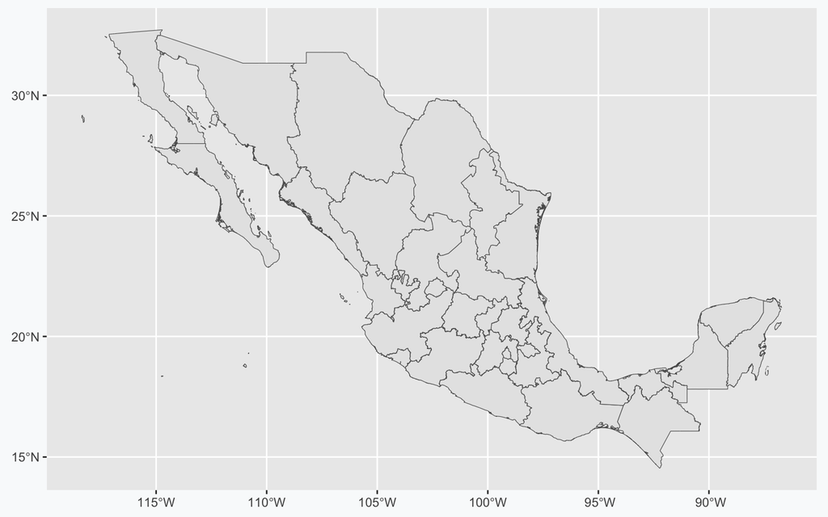

````markdown
```{r}
#| warning: false
#| message: false
#| fig-width: 8
#| fig-height: 5
ggplot() + geom_sf(data = mex)
```
````

## Chunk Options for Maps

A **tall** canvas. Same map, same code — but smaller, with space wasted.

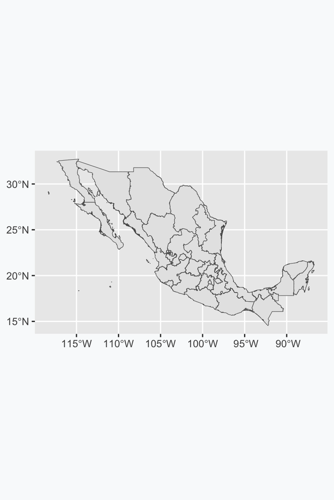

````markdown
```{r}
#| warning: false
#| message: false
#| fig-width: 4
#| fig-height: 6
ggplot() + geom_sf(data = mex)
```
````

## `embed-resources`: The Trap

You build an interactive map. It works on your laptop. You email your reader the `.html` file on its own, the way you would send any attachment.

**They see a blank white box.**

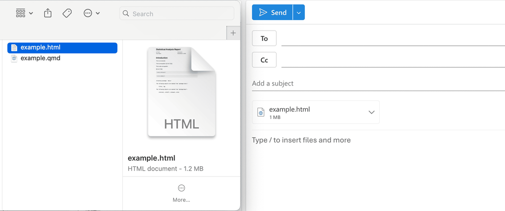

## Why It Happens

An HTML file by default *links* to its JavaScript, CSS, and images, which sit in a `_files` folder next to it. Send the HTML alone and every link breaks.

```yaml
---
format:
  html:
    embed-resources: true
---
```

This inlines everything into a single, larger, self-sufficient file.

**Important**

Set `embed-resources: true`, then send the `.html` file on its own. Nothing else needs to travel with it: no `_files` folder, no images. For anything you send to anyone this setting is not optional. We build a `leaflet` map in Session 3, which is usually when it bites.

## What Have We Learned?

- Built a Quarto document from an empty RStudio window, and rendered it
- **Code chunks**: `echo` and `eval` decide what the reader sees
- **`warning`** and **`message`** keep package chatter out of a report
- **`fig-width`** and **`fig-height`** set the canvas a map is drawn on
- **`embed-resources: true`**, then send the single `.html` file
- An `sf` layer reads quietly with `quiet = TRUE`, and `geom_sf()` draws it